# Regressão e Romance

Gabriel Morais Lúcio de Araújo

31 de julho de 2018

Neste relatório será abordado o assunto **Regressão Linear**. Serão utilizados dados sobre que atributos pessoas se interessam em encontro relâmpagos.

## Dados

Temos dados descrevendo 5000 encontros relâmpagos (speed dating) de 4 minutos envolvendo 310 jovens americanos. Os dados originais foram coletados por professores da Columbia Business School [no experimento descrito aqui](http://faculty.chicagobooth.edu/emir.kamenica/documents/genderDifferences.pdf).

```r
dados <- read_csv(here("dados/speed-dating.csv"),
                 progress = FALSE,
                 col_types =cols(.default = col_integer(),
                                 int_corr = col_double(),
                                 field = col_character(),
                                 from = col_character(),
                                 career = col_character(),
                                 attr = col_double(),
                                 samerace = col_character(),
                                 sinc = col_double(),
                                 intel = col_double(),
                                 fun = col_double(),
                                 amb = col_double(),
                                 shar = col_double(),
                                 like = col_double(),
                                 prob = col_double(),
                                 match_es = col_double(),
                                 attr3_s = col_double(),
                                 sinc3_s = col_double(),
                                 intel3_s = col_double(),
                                 fun3_s = col_double(),
                                 amb3_s = col_double())) %>%
  mutate(from = as.numeric(factor(from)),
         gender = as.numeric(factor(gender)),
         samerace = as.numeric(factor(samerace)))
```

## As variáveis

- iid : id do participante p1 no encontro
- gender : sexo do p1, 0 = mulher
- order : dos vários encontros realizados em uma noite, esse foi o n-ésimo, segundo essa variável
- pid : id do participante p2
- int_corr : correlação entre os interesses de p1 e p2
- samerace : p1 e p2 são da mesma raça?
- age_o : idade de p2
- age : idade de p1
- field : campo de estudo de p1
- race : raça de p1. O código é Black/African American=1; European/Caucasian-American=2; Latino/Hispanic American=3; Asian/Pacific Islander/Asian-American=4; Native American=5; Other=6
- from : de onde p1 é
- career : que carreira p1 quer seguir
- sports, tvsports, exercise, dining, museums, art, hiking, gaming, clubbing, reading, tv, theater, movies, concerts, music, shopping, yoga : De 1 a 10, quão interessado p1 é em cada uma dessas atividades.
- attr : quão atraente p1 achou p2
- sinc : quão sincero p1 achou p2
- intel : quão inteligente p1 achou p2
- fun : quão divertido p1 achou p2
- amb : quão ambicioso p1 achou p2
- shar : quanto p1 achou que compartilha interesses e hobbies com p2
- like : no geral, quanto p1 gostou de p2?
- prob : que probabiliade p1 acha que p2 tem de querer se encontrar novamente com p- (escala 1-10)
- attr3_s : quanto p1 acha que é atraente
- sinc3_s : quanto p1 acha que é sincero
- intel3_s : quanto p1 acha que é inteligente
- fun3_s : quanto p1 acha que é divertido
- amb3_s : quanto p1 acha que é ambicioso

Aqui uma amostra de algumas variáveis presentes nos dados:

```r
head = dados %>%
  select(gender, age, field, race, fun, intel, amb, sports, shar, like) %>%
  head()

kable(head)
```

| gender | age | field | race | fun | intel | amb | sports | shar | like |
| --- | --- | --- | --- | --- | --- | --- | --- | --- | --- |
| 1 | 21 | Law | 4 | 7 | 7 | 6 | 9 | 5 | 7 |
| 1 | 21 | Law | 4 | 8 | 7 | 5 | 9 | 6 | 7 |
| 1 | 21 | Law | 4 | 8 | 9 | 5 | 9 | 7 | 7 |
| 1 | 21 | Law | 4 | 7 | 8 | 6 | 9 | 8 | 7 |
| 1 | 21 | Law | 4 | 7 | 7 | 6 | 9 | 6 | 6 |
| 1 | 21 | Law | 4 | 4 | 7 | 6 | 9 | 4 | 6 |

## Explorando Variáveis

Primeiramente vamos conhecer melhor os dados, uma boa maneira de fazer isso é explorar as variáveis e tirar algumas conclusões antes da análise mais profunda que faremos a seguir. Vamos lá!

### Variáveis

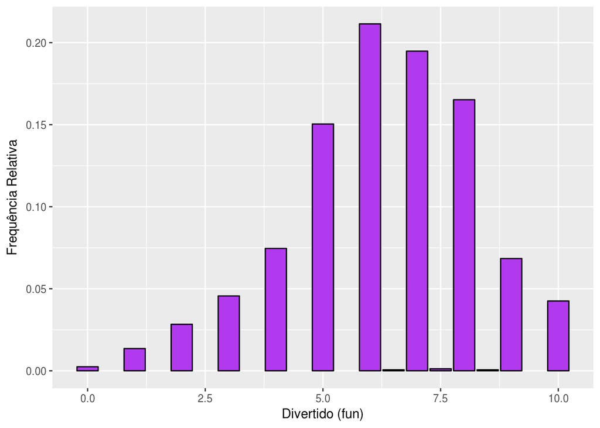

```r
dados %>%
  na.omit(fun) %>%
  ggplot(aes(fun, ..prop..)) +
  geom_bar(color = "black",
           fill = "darkorchid2") +
  labs(x= "Divertido (fun)",
       y = "Frequência Relativa")
```

- Divertido (fun): P1 da notas entre 6 e 7 para P2, na maioria das vezes, para o atributo divertido.

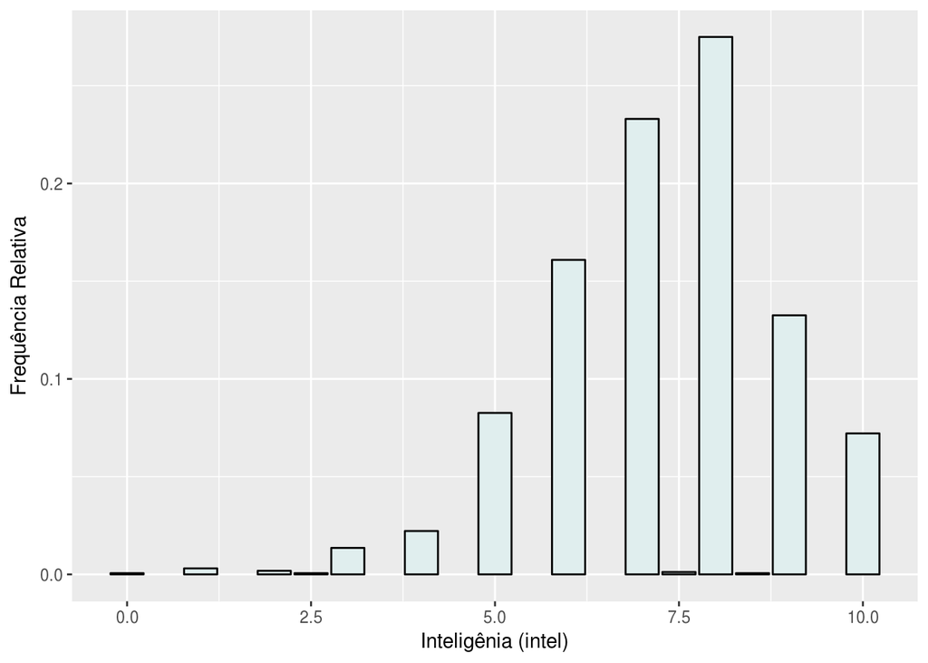

```r
dados %>%
  na.omit(intel) %>%
  ggplot(aes(intel, ..prop..)) +
  geom_bar(color = "black",
           fill = "azure2") +
  labs(x= "Inteligênia (intel)",
       y = "Frequência Relativa")
```

- Inteligência (intel): P1 da notas entre 7 e 8 para P2, na maioria das vezes, para o atributo inteligência.

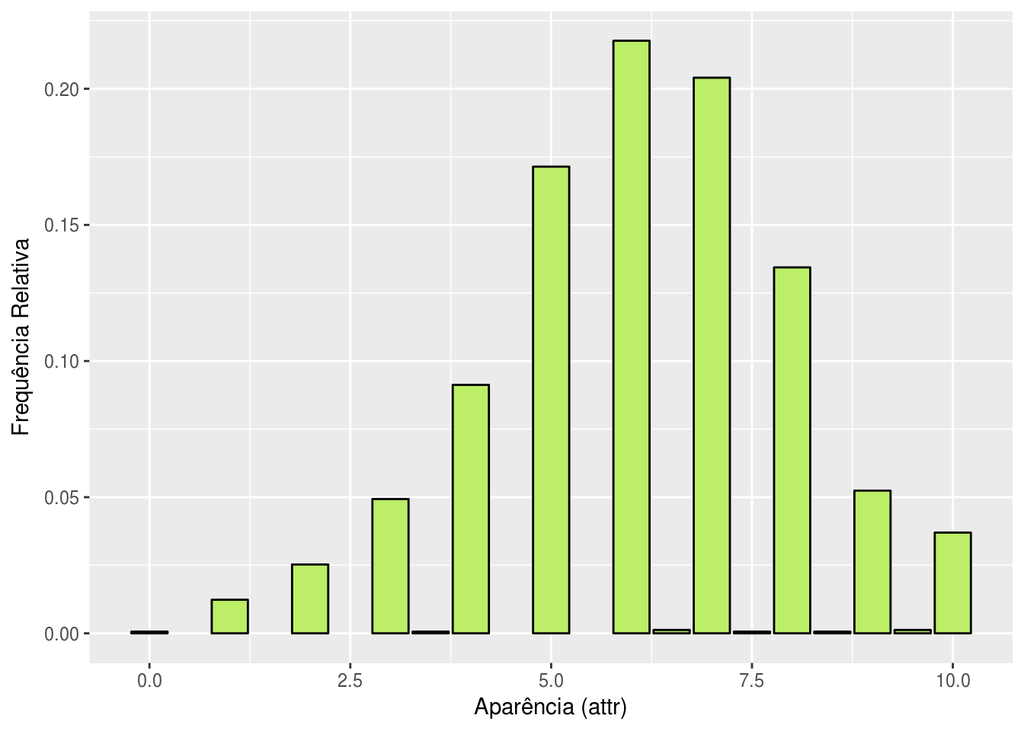

```r
dados %>%
  na.omit(attr) %>%
  ggplot(aes(attr, ..prop..)) +
  geom_bar(color = "black",
           fill = "darkolivegreen2") +
  labs(x= "Aparência (attr)",
       y = "Frequência Relativa")
```

- Aparência (attr): P1 da notas entre 5 e 7 para P2, na maioria das vezes, para o atributo aparência.

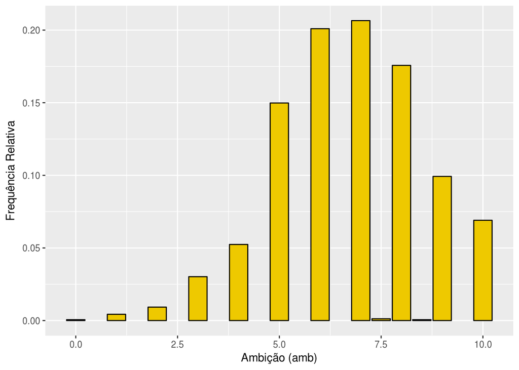

```r
dados %>%
  na.omit(amb) %>%
  ggplot(aes(amb, ..prop..)) +
  geom_bar(color = "black",
           fill = "gold2") +
  labs(x= "Ambição (amb)",
       y = "Frequência Relativa")
```

- Ambição (amb): P1 da notas entre 6 e 8 para P2, na maioria das vezes, para o atributo ambição.

- Geral: No geral foi possível observar que P1 geralmente acha P2 inteligente, porém nem sempre acha P2 atraente.

## Correlação entre as variáveis

Uma boa forma de encontrar um bom preditor para as variáveis é analisar as correlações entre elas nos dados, para isso vamos analisar o *corrplot* (gráfico de correlação) abaixo.

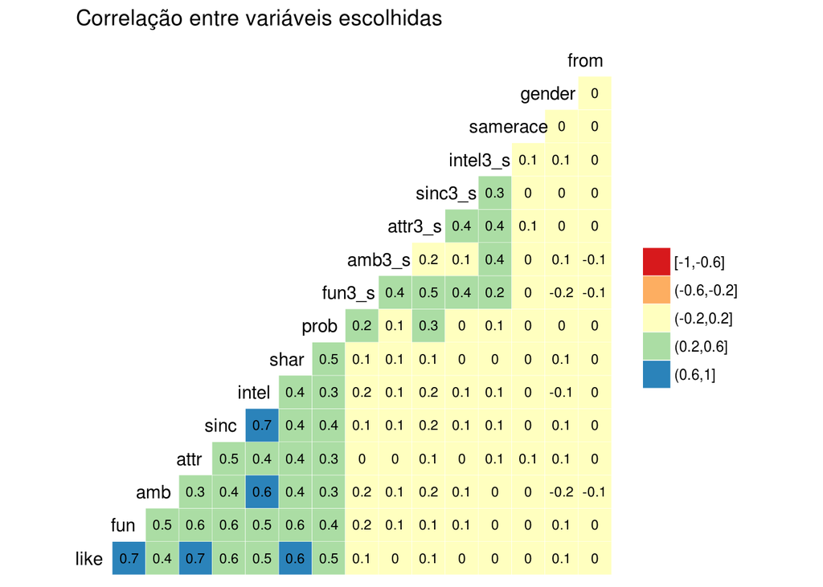

```r
dados %>%
  select(like,fun,amb,attr,
         sinc,intel,shar,prob,
         fun3_s,amb3_s,attr3_s,
         sinc3_s,intel3_s,samerace,
         gender,from) %>%
  na.omit() %>%
  ggcorr(palette = "Spectral", label = TRUE,
       hjust = 0.75, label_size = 3, nbreaks = 5) +
  ggtitle("Correlação entre variáveis escolhidas")
```

Com esse *corrplot* podemos notar algumas coisas:

- Dentre as variáveis que descrevem o que P1 acha de P2 (fun, amb, attr, sinc, intel, shar, prob), a variável ambição (amb) tem a menor correlação com *like*. Ou seja, você ser muito ambicioso não aumenta as notas recebedas nos likes dos speed-dates coletados.
- Dentre as variáveis que descrevem o que P1 acha de P2, as variáveis divertido (fun), aparência (attr) e aberto (shar) são as que possuem maior correlação com o *like*.
- Podemos ver também que inteligência (intel) possui correlações fortes com sinceridade (sinc) e ambição (amb).

## Analisando o relacionamento das variáveis *fun* e *attr* com *like*

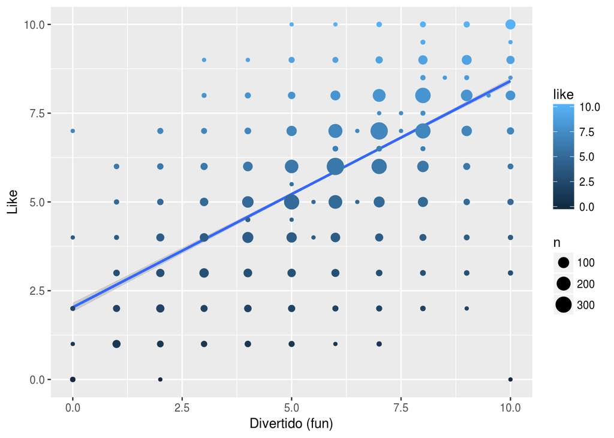

```r
dados %>%
  select(fun, like) %>%
  na.omit() %>%
  ggplot(aes(x = fun, y = like, color = like)) +
  geom_smooth(method=lm) +
  geom_count() +
  labs(x= "Divertido (fun)",
       y = "Like")
```

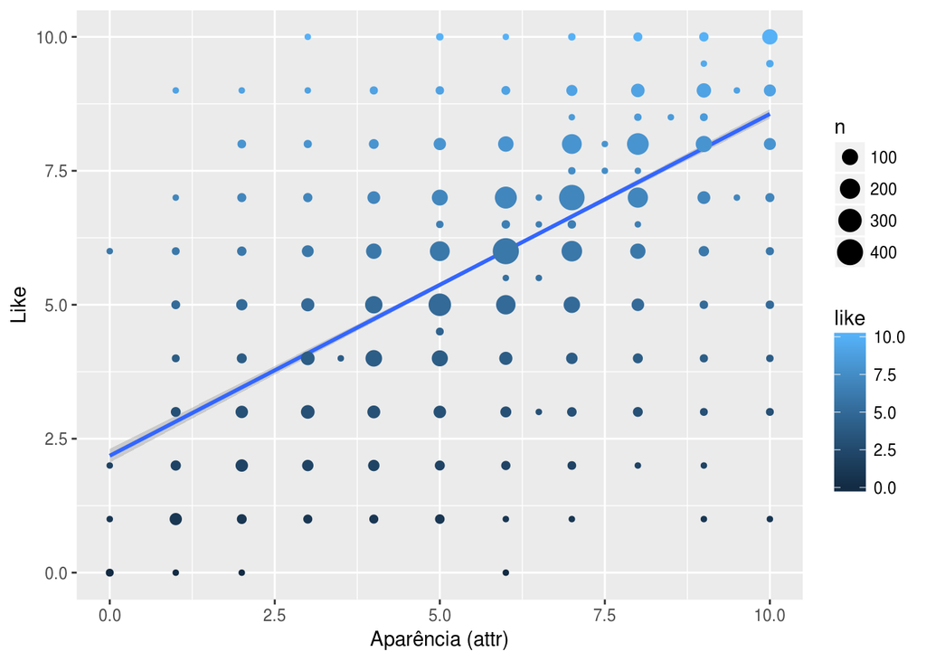

```r
dados %>%
  select(attr, like) %>%
  na.omit() %>%
  ggplot(aes(x = attr, y = like, color = like)) +
  geom_smooth(method=lm) +
  geom_count() +
  labs(x= "Aparência (attr)",
       y = "Like")
```

Como previsto pelo *corrplot*, as variáveis divertido (fun) e aparência (attr) realmente possuem uma boa correlação linear com like.

## Validação cruzada

A validação cruzada é uma técnica para avaliar a capacidade de generalização de um modelo, a partir de um conjunto de dados. Vamos usala para validar nosso modelo de regressão que será criado. Nesta análise vamos dividir os dados em treino e teste, divididos de forma aleatória.

```r
dados.mesma.escala = dados %>%  # apenas as variaveis de maior impacto com a variavel resposta (like)
  select(fun, prob, order, amb, attr, sinc, prob, shar, intel, like, gender, samerace) %>%
  na.omit() %>%
  mutate_at(.vars = vars(fun, prob, order,attr, sinc, prob, shar,intel),
             .funs = funs(as.numeric(scale(.))))

set.seed(101)
dados.mesma.escala$id <- 1:nrow(dados.mesma.escala)

treino = dados.mesma.escala %>% sample_frac(.8)
teste = anti_join(dados.mesma.escala, treino, by = 'id')
```

#### Modelo de regressão linear

Para nosso modelo de regressão vamos treiná-lo, utilizando os dados de treino, observando e ajustando R². Quando ele estiver bom o suficiente (analisando resíduos) vamos aplicá-lo nos dados de teste para validar o modelo (com a validação cruzada). Lembrando que nossa variável resposta para esta análise é o atributo **like**.

## Pergunta

- **Como o atributo divertido (fun) impacta em quanto P1 gosta de P2 (like)?**

## Análise

No nosso modelo iremos usar as variáveis de maior correlação com like, observadas anteriomente. Irei utilizar um alpha = 0.05 (nível de confiança).

```r
modelo <- lm(like ~ fun + attr + shar + sinc + prob + intel + amb, data = treino)

glance(modelo)
```

```
## # A tibble: 1 x 11
##   r.squared adj.r.squared sigma statistic p.value    df logLik   AIC   BIC
## *     <dbl>         <dbl> <dbl>     <dbl>   <dbl> <int>  <dbl> <dbl> <dbl>
## 1     0.680         0.679  1.05      992.       0     8 -4809. 9637. 9691.
## # ... with 2 more variables: deviance <dbl>, df.residual <int>
```

```r
tidy(modelo,
     conf.int = TRUE,
     conf.level = 0.95)
```

```
## # A tibble: 8 x 7
##   term        estimate std.error statistic   p.value conf.low conf.high
##   <chr>          <dbl>     <dbl>     <dbl>     <dbl>    <dbl>     <dbl>
## 1 (Intercept)   6.21      0.0915     67.9  0.          6.04     6.39
## 2 fun           0.427     0.0273     15.6  2.78e- 53   0.374    0.481
## 3 attr          0.627     0.0231     27.2  9.35e-147   0.581    0.672
## 4 shar          0.411     0.0250     16.5  1.63e- 58   0.362    0.460
## 5 sinc          0.138     0.0256      5.39 7.69e-  8   0.0878   0.188
## 6 prob          0.259     0.0211     12.3  7.70e- 34   0.218    0.300
## 7 intel         0.205     0.0281      7.27 4.50e- 13   0.149    0.260
## 8 amb          -0.0280    0.0134     -2.09 3.65e-  2  -0.0543  -0.00176
```

O modelo retornou um intercept positivo, com valores por volta de 6. Ou seja, de acordo com nosso modelo, P1 ira dar um like de 6 para P2. Vamos ver agora quais variáveis realmente possuem um impacto na nossa variável resposta.

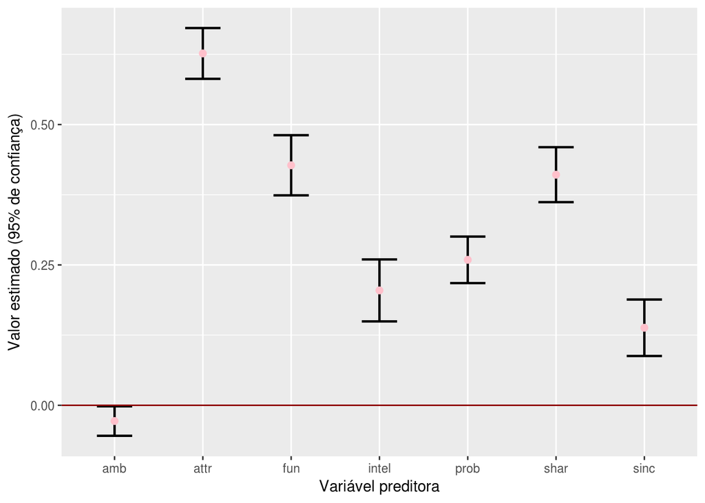

```r
tidy(modelo,
     conf.int = TRUE,
     conf.level = 0.95)  %>%
  filter(term != "(Intercept)") %>%
  ggplot(aes(term, estimate, ymin = conf.low, ymax = conf.high)) +
  geom_errorbar(size = 0.8, width= 0.4) +
  geom_point(color = "pink", size = 2) +
  geom_hline(yintercept = 0, colour = "darkred") +
  labs(x = "Variável preditora",
       y = "Valor estimado (95% de confiança)")
```

### Resíduos

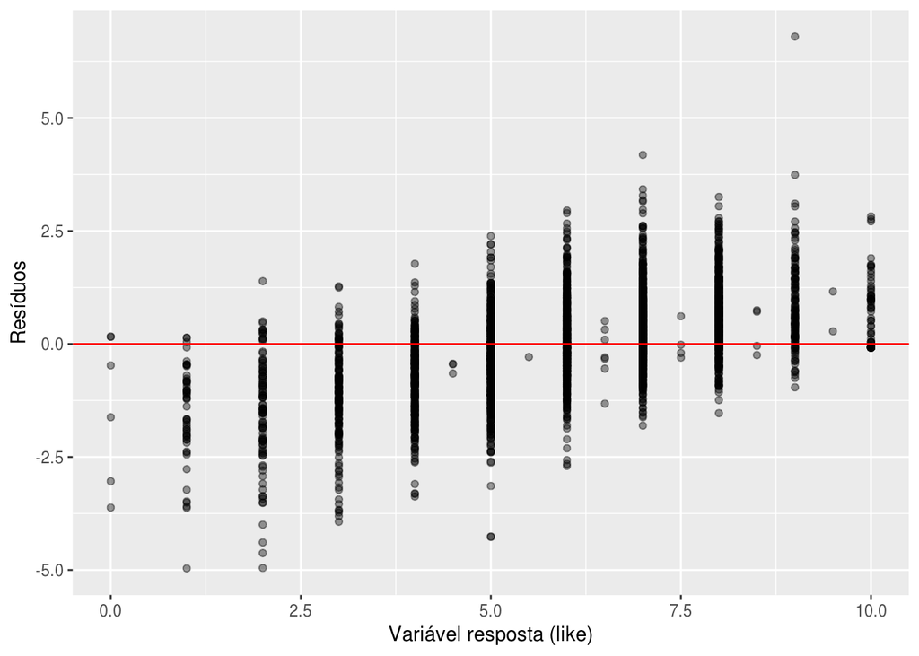

```r
resid_data <- data.frame(resid(modelo), rstandard(modelo), treino$like, stringsAsFactors=FALSE)

resid_data %>%
  ggplot(aes(treino$like, resid(modelo))) +
  geom_point(alpha = 0.4) +
  geom_hline(yintercept = 0,
             color = "red") +
  labs(x = "Variável resposta (like)", y = "Resíduos")
```

### Predição (validação cruzada)

```r
predicoes <- modelo %>% predict(teste)

data.frame( R2 = caret::R2(predicoes, teste$like),
            RMSE = caret::RMSE(predicoes, teste$like),
            ERR = caret::RMSE(predicoes, teste$like)/
              mean(teste$like))
```

```
##          R2    RMSE       ERR
## 1 0.6551181 1.10175 0.1815768
```

Nosso modelo realmente não está muito bom, existem partes a ser melhoradas para um ganho no acerto das predições.

### Resposta para nossa pergunta

- **Como o atributo divertido (fun) impacta em quanto P1 gosta de P2 (like)?**

Com 95% de significância podemos dizer que fun é relevante para o modelo, ficando apenas atrás de attr e que fun teve um impacto positivo no like recebido pelos participantes.